# RV預測project

### Part 4 : 深度學習模型訓練

### pyTorch LSTM架設、分別用RV & RV+IV進行訓練

# 歡迎來到我們的RV預測Project第四集!!

### 根據Part 3的資料視覺化後，我們將IV做些轉換成為LSTM的訓練資料

根據 從Part 3的資料可以發現選擇權IV的微笑曲線，在極端情況下曲度更為劇烈，然而這些**深價外**的選擇權有著**極高的IV**與**極低的成交量**，故我想利用成交量來做IV的加權平均，去找出代表該日收盤的IV代表值，並以此作為模型輸入。

利用成交量加權平均的好處為可以考慮到極端現象，IV的變化，過往論文是將選擇權依**價性指標(Moneyness)**將選擇權分為5類，並以一天5個資料作為模型輸入，這也是一種可行的方法，但5類價性指標的區分為自由設置，且沒有考量到成交量，意味著作為模型輸入的深價外與價內的IV有著相同的重要性，但事實上是兩者的交易量差距非常大。

### 在Part 4的部分，我們有以下的訓練流程

1. 再次確認實際訓練的交易日期
2. 計算每日的IV加權平均，並存入我們的`RV_predict_project.db`
3. 用`pyTorch`來建立LSTM模型，並分別訓練
   - 單純RV做input去預測下一日的RV
   - 同時用RV跟IV加權平均做input去預測下一日的RV
4. 以`昨天的RV來當成明天的RV，這個naive的方式作為模型的Baseline`，並比較3者在樣本外的預測表現。
5. 繪圖出樣本外的預測圖與模型Loss比較

### 1. 確認實際訓練的交易日期

我們在前面提到，由於台灣證交所從2014/12/29日開始提供5秒大盤日資料，故我們以該日作為訓練的初始日期。  
實際訓練交易日期：2014/12/29~2022/5/24  
我們先比較在這些交易日中，是否都有**大盤的daily_RV、選擇權收盤日資料以及無風險利率日資料**

### 將每日的IV依據成交量做加權平均，使每日得到一個IV的代表值

```python
import pandas as pd
import sqlite3
import numpy as np
from datetime import datetime, timedelta
from calendar import WEDNESDAY
from get_data_db import  get_Risk_free_IR, get_daily_RV, get_close_optData,  get_daily_close_TAIEX, get_vector_IV
```

```python
# 讀db的資料
db_path = '/Users/robert/Documents/碩士畢業論文/Code_and_db/RV_predict_project.db'
conn = sqlite3.connect(db_path, timeout = 20)
conn
```

```
<sqlite3.Connection at 0x7f8b939596c0>
```

#### 讀取大盤daily_RV

```python
RV_df = pd.read_sql_query("SELECT * FROM daily_RV", conn)
RV_df.head()
```

|  | 日期 | daily_RV |
| --- | --- | --- |
| 0 | 20121101 | 0.103753 |
| 1 | 20121102 | 0.134957 |
| 2 | 20121105 | 0.083747 |
| 3 | 20121106 | 0.108343 |
| 4 | 20121107 | 0.077682 |

```python
RV_df_t = RV_df[(RV_df['日期'] >= '20141229') &(RV_df['日期'] <= '20220524') ]
RV_df_t
```

|  | 日期 | daily_RV |
| --- | --- | --- |
| 533 | 20141229 | 0.255503 |
| 534 | 20141230 | 0.287908 |
| 535 | 20141231 | 0.230002 |
| 536 | 20150105 | 0.252687 |
| 537 | 20150106 | 0.319356 |
| ... | ... | ... |
| 2334 | 20220518 | 0.278163 |
| 2335 | 20220519 | 0.336131 |
| 2336 | 20220520 | 0.231467 |
| 2337 | 20220523 | 0.211057 |
| 2338 | 20220524 | 0.269991 |

1806 rows × 2 columns

#### 讀取option每日收盤價

```python
opt_df = pd.read_sql_query("SELECT * FROM TXO_option", conn)
```

```python
opt_df
```

|  | 交易日期 | 契約 | 到期月份_週別 | 履約價 | 買賣權 | 開盤價 | 最高價 | 最低價 | 收盤價 | 成交量 | 結算價 | 未沖銷契約數 | 最後最佳買價 | 最後最佳賣價 | 歷史最高價 | 歷史最低價 |
| --- | --- | --- | --- | --- | --- | --- | --- | --- | --- | --- | --- | --- | --- | --- | --- | --- |
| 0 | 20070102 | TXO | 200701 | 6500.0 | 買權 | 1410.0 | 1410.0 | 1410.0 | 1410.0 | 2 | 1430.0 | 285 | 1430.0 | 1540.0 | 1410.0 | 630.0 |
| 1 | 20070102 | TXO | 200701 | 6500.0 | 賣權 | 1.7 | 1.7 | 0.5 | 1.2 | 925 | 0.5 | 5955 | 0.5 | 1.1 | 81.0 | 0.5 |
| 2 | 20070102 | TXO | 200701 | 6600.0 | 買權 | 0.0 | 0.0 | 0.0 | 0.0 | 0 | 1330.0 | 114 | 1330.0 | 1440.0 | 1210.0 | 775.0 |
| 3 | 20070102 | TXO | 200701 | 6600.0 | 賣權 | 1.1 | 1.5 | 1.0 | 1.0 | 888 | 1.0 | 6086 | 1.0 | 1.5 | 90.0 | 1.0 |
| 4 | 20070102 | TXO | 200701 | 6700.0 | 買權 | 1200.0 | 1200.0 | 1200.0 | 1200.0 | 10 | 1230.0 | 140 | 1230.0 | 1340.0 | 1200.0 | 650.0 |
| ... | ... | ... | ... | ... | ... | ... | ... | ... | ... | ... | ... | ... | ... | ... | ... | ... |
| 1978867 | 20220524 | TXO | 202212 | 21200.0 | 賣權 | - | - | - | - | 0 | - | - | - | - | - | - |
| 1978868 | 20220524 | TXO | 202212 | 21400.0 | 買權 | 11.0 | 11.0 | 10.5 | 10.5 | 7 | 10.5 | 170 | 7.5 | 11.0 | 49.0 | 0.8 |
| 1978869 | 20220524 | TXO | 202212 | 21400.0 | 買權 | - | - | - | - | 0 | - | - | - | - | - | - |
| 1978870 | 20220524 | TXO | 202212 | 21400.0 | 賣權 | - | - | - | - | 0 | 6100.0 | 0 | - | - | - | - |
| 1978871 | 20220524 | TXO | 202212 | 21400.0 | 賣權 | - | - | - | - | 0 | - | - | - | - | - | - |

1978872 rows × 16 columns

```python
opt_df_t = opt_df[opt_df['交易日期'] >= '20141229']
opt_df_t
```

|  | 交易日期 | 契約 | 到期月份_週別 | 履約價 | 買賣權 | 開盤價 | 最高價 | 最低價 | 收盤價 | 成交量 | 結算價 | 未沖銷契約數 | 最後最佳買價 | 最後最佳賣價 | 歷史最高價 | 歷史最低價 |
| --- | --- | --- | --- | --- | --- | --- | --- | --- | --- | --- | --- | --- | --- | --- | --- | --- |
| 537200 | 20141229 | TXO | 201412W5 | 8400.0 | 買權 | 930.0 | 930.0 | 930.0 | 930.0 | 1 | 905.0 | 1 | 890.0 | 930.0 | 930.0 | 930.0 |
| 537201 | 20141229 | TXO | 201412W5 | 8400.0 | 賣權 | 0.4 | 0.5 | 0.4 | 0.5 | 15 | 0.2 | 220 | 0.1 | 0.3 | 0.6 | 0.3 |
| 537202 | 20141229 | TXO | 201412W5 | 8500.0 | 買權 | 790.0 | 790.0 | 790.0 | 790.0 | 1 | 805.0 | 1 | 790.0 | 830.0 | 790.0 | 790.0 |
| 537203 | 20141229 | TXO | 201412W5 | 8500.0 | 賣權 | 0.0 | 0.0 | 0.0 | 0.0 | 0 | 0.2 | 530 | 0.1 | 0.3 | 0.7 | 0.4 |
| 537204 | 20141229 | TXO | 201412W5 | 8600.0 | 買權 | 0.0 | 0.0 | 0.0 | 0.0 | 0 | 705.0 | 0 | 690.0 | 730.0 | 0.0 | 0.0 |
| ... | ... | ... | ... | ... | ... | ... | ... | ... | ... | ... | ... | ... | ... | ... | ... | ... |
| 1978867 | 20220524 | TXO | 202212 | 21200.0 | 賣權 | - | - | - | - | 0 | - | - | - | - | - | - |
| 1978868 | 20220524 | TXO | 202212 | 21400.0 | 買權 | 11.0 | 11.0 | 10.5 | 10.5 | 7 | 10.5 | 170 | 7.5 | 11.0 | 49.0 | 0.8 |
| 1978869 | 20220524 | TXO | 202212 | 21400.0 | 買權 | - | - | - | - | 0 | - | - | - | - | - | - |
| 1978870 | 20220524 | TXO | 202212 | 21400.0 | 賣權 | - | - | - | - | 0 | 6100.0 | 0 | - | - | - | - |
| 1978871 | 20220524 | TXO | 202212 | 21400.0 | 賣權 | - | - | - | - | 0 | - | - | - | - | - | - |

1441672 rows × 16 columns

#### 讀取無風險利率日資料

```python
IR_df = pd.read_sql_query("SELECT * FROM interest_rate_table ", conn)
IR_df
```

|  | 日期 | 利率 |
| --- | --- | --- |
| 0 | 20141229 | 0.388 |
| 1 | 20141230 | 0.388 |
| 2 | 20141231 | 0.392 |
| 3 | 20150105 | 0.385 |
| 4 | 20150106 | 0.386 |
| ... | ... | ... |
| 1838 | 20220606 | 0.182 |
| 1839 | 20220607 | 0.181 |
| 1840 | 20220608 | 0.183 |
| 1841 | 20220609 | 0.181 |
| 1842 | 20220610 | 0.182 |

1843 rows × 2 columns

```python
IR_df_t = IR_df[(IR_df['日期'] >= '20141229') & (IR_df['日期'] <= '20220524')]
IR_df_t
```

|  | 日期 | 利率 |
| --- | --- | --- |
| 0 | 20141229 | 0.388 |
| 1 | 20141230 | 0.388 |
| 2 | 20141231 | 0.392 |
| 3 | 20150105 | 0.385 |
| 4 | 20150106 | 0.386 |
| ... | ... | ... |
| 1826 | 20220518 | 0.180 |
| 1827 | 20220519 | 0.181 |
| 1828 | 20220520 | 0.182 |
| 1829 | 20220523 | 0.182 |
| 1830 | 20220524 | 0.180 |

1831 rows × 2 columns

```python
# 比較 大盤daily_RV有資料時，option有無收盤價資訊
set(RV_df_t['日期']) ^ set(opt_df_t['交易日期'])
```

```
set()
```

可見daily_RV資料與選擇權收盤日資料時間都有對上，再來看看那些日子中有沒有無風險利率的資料

```python
# 這邊用相減，因爲金融業隔夜拆款利率在春節期間仍會公布，但股市休市
set(RV_df_t['日期']) - set(IR_df_t['日期'])
```

```
set()
```

可見在台股有交易的日子，也都有對應的無風險利率資料，因此我們可以將交易日子整理出來存在`trading_date`這個`list`中。

```python
# 這邊用unique不用set，是因爲set裡沒有順序
trading_date = RV_df_t['日期'].unique()
trading_date
```

```
array(['20141229', '20141230', '20141231', ..., '20220520', '20220523',
       '20220524'], dtype=object)
```

### 計算每日的IV加權平均，並存入我們的RV_predict_project.db

確定好交易日期後，我們來計算該期間內的**每日IV加權平均**

```python
import py_vollib_vectorized
import warnings
warnings.filterwarnings("ignore")
```

```python
# 在Part 2寫好的選擇權剩餘日期計算器
def get_due_date(cal_date):

    cal_date = datetime.strptime(cal_date, '%Y%m%d')
    if cal_date.weekday() < WEDNESDAY: # 特定交易日 為禮拜一or二 故到期日也是'那個'禮拜三
        delta = WEDNESDAY - cal_date.weekday()
        due_date = cal_date + timedelta(days=delta)
        due_date_delta = due_date.weekday() - cal_date.weekday()

    elif cal_date.weekday() >= WEDNESDAY: # 特定交易日 為禮拜三四五 故到期日是'下個'禮拜三 +5
        delta = cal_date.weekday() - WEDNESDAY
        due_date = cal_date + timedelta(days=(7 - delta))
        due_date_delta = due_date.weekday() - cal_date.weekday() + 5

    return due_date, due_date_delta
```

```python
# 在Part 2寫好的選擇權IV向量計算器
def get_vector_IV_test(df, TAIEX_close_price, due_day, IR):
    opt_df = df[df['買賣權'] == '買權']
    # 將成交量為0的去除
    opt_df =  opt_df[~(opt_df['成交量'] == 0)]
    price = opt_df['收盤價'] # 權利金 也就是選擇權的收盤價
    S = TAIEX_close_price # 台股當時指數
    K = opt_df['履約價']
    t = due_day / 252 # 轉換成年 用交易日252日
    r = IR # 無風險利率
    flag = ['c']
    opt_df['IV'] = py_vollib_vectorized.vectorized_implied_volatility(price, S, K, t, r, flag, q=0, model='black_scholes_merton',return_as='numpy')  # equivalent

    return opt_df
```

```python
# 測試 將剛剛交易日loop過一遍 並算出每日IV加權平均
for date in ['20200312','20200313']:
    print(date)
    closed_price = get_daily_close_TAIEX(date, conn)
    df = get_close_optData(date, conn)
    due_day = get_due_date(date)[1]
    IR = get_Risk_free_IR(date, conn)
    print(f'{closed_price=}, {due_day=}, {IR=}')

    # 計算出IV
    IV_opt = get_vector_IV_test(df, closed_price, due_day, IR)
    print(IV_opt[['履約價','收盤價','成交量','IV']])

    # 將IV做加權平均
    IV_opt.dropna(inplace = True)
    IV_opt['成交量比率'] = IV_opt['成交量'] /  IV_opt['成交量'].sum()
    IV_opt['IV加權'] = IV_opt['IV'] * IV_opt['成交量比率']
    print(f'{date}的IV加權為:', IV_opt['IV加權'].sum() )
```

```
20200312
沒有週選擇權資料, 故找最近的月選
closed_price=10422.32, due_day=4, IR=0.00178
         履約價    收盤價    成交量        IV
22    9800.0  610.0     61       NaN
24    9900.0  515.0     56       NaN
26   10000.0  465.0    465  0.350941
28   10100.0  380.0    575  0.335279
30   10200.0  310.0   1861  0.341293
32   10300.0  243.0   9272  0.335878
34   10400.0  184.0  18257  0.329594
36   10500.0  134.0  26685  0.323145
38   10600.0   91.0  30553  0.311816
40   10650.0   71.0  15260  0.301374
42   10700.0   56.0  32074  0.296358
```

[output cut: 92 more lines]

```python
IV_data_list = []
```

```python
# loop過全部的交易日期，並將結果以tuple的方式存在IV_data_list中
for date in trading_date:
    print(date)
    closed_price = get_daily_close_TAIEX(date, conn)
    df = get_close_optData(date, conn)
    due_day = get_due_date(date)[1]
    IR = get_Risk_free_IR(date, conn)
    print(f'{closed_price=}, {due_day=}, {IR=}')

    # 計算出IV
    IV_opt = get_vector_IV_test(df, closed_price, due_day, IR)
    #print(IV_opt[['履約價','收盤價','成交量','IV']])

    # 將IV做加權平均
    IV_opt.dropna(inplace = True)
    IV_opt['成交量比率'] = IV_opt['成交量'] /  IV_opt['成交量'].sum()
    IV_opt['IV加權'] = IV_opt['IV'] * IV_opt['成交量比率']
    print(f'{date}的IV加權為:', IV_opt['IV加權'].sum() )
    data_tuple = (date, closed_price, due_day,IR ,IV_opt['IV加權'].sum())
    IV_data_list.append(data_tuple)
```

```python
df = pd.DataFrame(data = IV_data_list, columns = ['日期', '大盤收盤價', '距離到期日','無風險利率' ,'IV加權'])
df
```

|  | 日期 | 大盤收盤價 | 距離到期日 | 無風險利率 | IV加權 |
| --- | --- | --- | --- | --- | --- |
| 0 | 20141229 | 9286.28 | 2 | 0.00388 | 0.147846 |
| 1 | 20141230 | 9268.43 | 1 | 0.00388 | 0.152201 |
| 2 | 20141231 | 9307.26 | 5 | 0.00392 | 0.019378 |
| 3 | 20150105 | 9274.11 | 2 | 0.00385 | 0.084940 |
| 4 | 20150106 | 9048.34 | 1 | 0.00386 | 0.188207 |
| ... | ... | ... | ... | ... | ... |
| 1823 | 20220518 | 16296.86 | 5 | 0.00180 | 0.127117 |
| 1824 | 20220519 | 16020.32 | 4 | 0.00181 | 0.157531 |
| 1825 | 20220520 | 16144.85 | 3 | 0.00182 | 0.186008 |
| 1826 | 20220523 | 16156.41 | 2 | 0.00182 | 0.196686 |
| 1827 | 20220524 | 15963.63 | 1 | 0.00180 | 0.181011 |

1828 rows × 5 columns

不太對勁，理論上只有1806筆資料的才對，為什麼組後算出來有1828個row

```python
group_by_df = df.groupby('日期').count()
group_by_df
```

| 日期 | 大盤收盤價 | 距離到期日 | 無風險利率 | IV加權 |
| --- | --- | --- | --- | --- |
| 20141229 | 3 | 3 | 3 | 3 |
| 20141230 | 3 | 3 | 3 | 3 |
| 20141231 | 3 | 3 | 3 | 3 |
| 20150105 | 3 | 3 | 3 | 3 |
| 20150106 | 2 | 2 | 2 | 2 |
| ... | ... | ... | ... | ... |
| 20220518 | 1 | 1 | 1 | 1 |
| 20220519 | 1 | 1 | 1 | 1 |
| 20220520 | 1 | 1 | 1 | 1 |
| 20220523 | 1 | 1 | 1 | 1 |
| 20220524 | 1 | 1 | 1 | 1 |

1806 rows × 4 columns

資料竟然有重複! 檢查看看是哪一些有重複的

```python
group_by_df[group_by_df['大盤收盤價'] != 1]
```

| 日期 | 大盤收盤價 | 距離到期日 | 無風險利率 | IV加權 |
| --- | --- | --- | --- | --- |
| 20141229 | 3 | 3 | 3 | 3 |
| 20141230 | 3 | 3 | 3 | 3 |
| 20141231 | 3 | 3 | 3 | 3 |
| 20150105 | 3 | 3 | 3 | 3 |
| 20150106 | 2 | 2 | 2 | 2 |
| 20150107 | 2 | 2 | 2 | 2 |
| 20150108 | 2 | 2 | 2 | 2 |
| 20150109 | 2 | 2 | 2 | 2 |
| 20150112 | 2 | 2 | 2 | 2 |
| 20150113 | 2 | 2 | 2 | 2 |
| 20150114 | 2 | 2 | 2 | 2 |
| 20150115 | 2 | 2 | 2 | 2 |
| 20150116 | 2 | 2 | 2 | 2 |
| 20150119 | 2 | 2 | 2 | 2 |
| 20150120 | 2 | 2 | 2 | 2 |
| 20150121 | 2 | 2 | 2 | 2 |
| 20150122 | 2 | 2 | 2 | 2 |
| 20150123 | 2 | 2 | 2 | 2 |

```python
# 有問題的日期
dup_date = group_by_df[group_by_df['大盤收盤價'] != 1].index
dup_date
```

```
Index(['20141229', '20141230', '20141231', '20150105', '20150106', '20150107',
       '20150108', '20150109', '20150112', '20150113', '20150114', '20150115',
       '20150116', '20150119', '20150120', '20150121', '20150122', '20150123'],
      dtype='object', name='日期')
```

```python
# 隨機查看有問題的日期
df[df['日期'] == '20141229']
```

|  | 日期 | 大盤收盤價 | 距離到期日 | 無風險利率 | IV加權 |
| --- | --- | --- | --- | --- | --- |
| 0 | 20141229 | 9286.28 | 2 | 0.00388 | 0.147846 |
| 18 | 20141229 | 9286.28 | 2 | 0.00388 | 0.147846 |
| 22 | 20141229 | 9286.28 | 2 | 0.00388 | 0.147846 |

```python
df[df['日期'] == '20150120']
```

|  | 日期 | 大盤收盤價 | 距離到期日 | 無風險利率 | IV加權 |
| --- | --- | --- | --- | --- | --- |
| 14 | 20150120 | 9251.69 | 1 | 0.00387 | 0.167729 |
| 36 | 20150120 | 9251.69 | 1 | 0.00387 | 0.167729 |

推測為原始option資料有重複吧，不過沒關係。  
我們可以用`drop_duplicates`將完全重複的資料刪去，若裡面資料不相同就不會被drop掉  
若是在`drop_duplicates`後筆數還對不上，代表資料中間的計算有問題，那樣就很麻煩了。

```python
# 我們在test_df上做測試
test_df = df.copy()
test_df.drop_duplicates(subset = df.columns, inplace = True, ignore_index = True)
```

```python
test_df
```

|  | 日期 | 大盤收盤價 | 距離到期日 | 無風險利率 | IV加權 |
| --- | --- | --- | --- | --- | --- |
| 0 | 20141229 | 9286.28 | 2 | 0.00388 | 0.147846 |
| 1 | 20141230 | 9268.43 | 1 | 0.00388 | 0.152201 |
| 2 | 20141231 | 9307.26 | 5 | 0.00392 | 0.019378 |
| 3 | 20150105 | 9274.11 | 2 | 0.00385 | 0.084940 |
| 4 | 20150106 | 9048.34 | 1 | 0.00386 | 0.188207 |
| ... | ... | ... | ... | ... | ... |
| 1801 | 20220518 | 16296.86 | 5 | 0.00180 | 0.127117 |
| 1802 | 20220519 | 16020.32 | 4 | 0.00181 | 0.157531 |
| 1803 | 20220520 | 16144.85 | 3 | 0.00182 | 0.186008 |
| 1804 | 20220523 | 16156.41 | 2 | 0.00182 | 0.196686 |
| 1805 | 20220524 | 15963.63 | 1 | 0.00180 | 0.181011 |

1806 rows × 5 columns

太棒了!資料筆數正確無誤，可以繼續存至db中了

```python
test_df.to_sql('daily_IV', conn, if_exists = 'replace', index = None)
```

```
1806
```

```python
IV_df = pd.read_sql_query("SELECT * FROM daily_IV", conn)
IV_df
```

|  | 日期 | 大盤收盤價 | 距離到期日 | 無風險利率 | IV加權 |
| --- | --- | --- | --- | --- | --- |
| 0 | 20141229 | 9286.28 | 2 | 0.00388 | 0.147846 |
| 1 | 20141230 | 9268.43 | 1 | 0.00388 | 0.152201 |
| 2 | 20141231 | 9307.26 | 5 | 0.00392 | 0.019378 |
| 3 | 20150105 | 9274.11 | 2 | 0.00385 | 0.084940 |
| 4 | 20150106 | 9048.34 | 1 | 0.00386 | 0.188207 |
| ... | ... | ... | ... | ... | ... |
| 1801 | 20220518 | 16296.86 | 5 | 0.00180 | 0.127117 |
| 1802 | 20220519 | 16020.32 | 4 | 0.00181 | 0.157531 |
| 1803 | 20220520 | 16144.85 | 3 | 0.00182 | 0.186008 |
| 1804 | 20220523 | 16156.41 | 2 | 0.00182 | 0.196686 |
| 1805 | 20220524 | 15963.63 | 1 | 0.00180 | 0.181011 |

1806 rows × 5 columns

### 每日IV計算完成，並順利的儲存在db中

### 3. 用pyTorch來建立LSTM模型，並分別訓練

- 單純RV做input去預測下一日的RV
- 同時用RV跟IV加權平均做input去預測下一日的RV

這部分比較複雜，我們會再依以下流程處理

1. 用`pyTorch`所提供的DataLoader，將我們的訓練資料(RV, IV)放進去，到時`pyTorch`會搞定好batch設定以每一筆的訓練X跟Y。
2. 用`pyTorch`架設LSTM模型，我們會檢查一下輸入跟輸出的維度是否與我們的要求相符
3. 準備好hyper-parameter，一些可以調整的參數，如一次要輸入多少過去的RV來做預測、LSTM block要疊幾層等。
4. 寫好訓練用的Loop，並紀錄loss的狀況

```python
import torch #pytorch
import torch.nn as nn
from torch.utils.data import Dataset, DataLoader
```

### 1. `pyTorch DataLoader`建立

我們先一步一步做完一輪，到時全部包在DataLoader這個物件裡面

```python
#從db中讀取RV資料
db_path =  '/Users/robert/Documents/碩士畢業論文/Code_and_db/RV_predict_project.db'
conn = sqlite3.connect(db_path, timeout = 20)
RV_data = pd.read_sql_query("SELECT * FROM Daily_RV", conn)
IV_data = pd.read_sql_query("SELECT * FROM daily_IV", conn)
```

```python
RV_data = RV_data[RV_data['日期'] <= '20220524']
RV_data
```

|  | 日期 | daily_RV |
| --- | --- | --- |
| 0 | 20160104 | 0.497078 |
| 1 | 20160105 | 0.524352 |
| 2 | 20160106 | 0.532219 |
| 3 | 20160107 | 0.508205 |
| 4 | 20160108 | 0.530575 |
| ... | ... | ... |
| 1554 | 20220518 | 0.420785 |
| 1555 | 20220519 | 0.507711 |
| 1556 | 20220520 | 0.349904 |
| 1557 | 20220523 | 0.319220 |
| 1558 | 20220524 | 0.407964 |

1559 rows × 2 columns

```python
IV_data = IV_data[IV_data['日期'] >= '20160101']
IV_data
```

|  | 日期 | 大盤收盤價 | 距離到期日 | 無風險利率 | IV加權 |
| --- | --- | --- | --- | --- | --- |
| 247 | 20160104 | 8114.26 | 2 | 0.00235 | 0.153985 |
| 248 | 20160105 | 8075.11 | 1 | 0.00232 | 0.150774 |
| 249 | 20160106 | 7990.39 | 5 | 0.00232 | 0.163454 |
| 250 | 20160107 | 7852.06 | 4 | 0.00232 | 0.172884 |
| 251 | 20160108 | 7893.97 | 3 | 0.00232 | 0.192513 |
| ... | ... | ... | ... | ... | ... |
| 1801 | 20220518 | 16296.86 | 5 | 0.00180 | 0.127117 |
| 1802 | 20220519 | 16020.32 | 4 | 0.00181 | 0.157531 |
| 1803 | 20220520 | 16144.85 | 3 | 0.00182 | 0.186008 |
| 1804 | 20220523 | 16156.41 | 2 | 0.00182 | 0.196686 |
| 1805 | 20220524 | 15963.63 | 1 | 0.00180 | 0.181011 |

1559 rows × 5 columns

```python
IV_data.reset_index(drop = True, inplace = True)
```

將RV跟IV的dataframe依照日期合併再一起，以確保在訓練的時候資料不會出錯。

```python
combine_df = RV_data.merge(IV_data, how='left', left_on='日期', right_on = '日期')
combine_df
```

|  | 日期 | daily_RV | 大盤收盤價 | 距離到期日 | 無風險利率 | IV加權 |
| --- | --- | --- | --- | --- | --- | --- |
| 0 | 20160104 | 0.497078 | 8114.26 | 2 | 0.00235 | 0.153985 |
| 1 | 20160105 | 0.524352 | 8075.11 | 1 | 0.00232 | 0.150774 |
| 2 | 20160106 | 0.532219 | 7990.39 | 5 | 0.00232 | 0.163454 |
| 3 | 20160107 | 0.508205 | 7852.06 | 4 | 0.00232 | 0.172884 |
| 4 | 20160108 | 0.530575 | 7893.97 | 3 | 0.00232 | 0.192513 |
| ... | ... | ... | ... | ... | ... | ... |
| 1554 | 20220518 | 0.420785 | 16296.86 | 5 | 0.00180 | 0.127117 |
| 1555 | 20220519 | 0.507711 | 16020.32 | 4 | 0.00181 | 0.157531 |
| 1556 | 20220520 | 0.349904 | 16144.85 | 3 | 0.00182 | 0.186008 |
| 1557 | 20220523 | 0.319220 | 16156.41 | 2 | 0.00182 | 0.196686 |
| 1558 | 20220524 | 0.407964 | 15963.63 | 1 | 0.00180 | 0.181011 |

1559 rows × 6 columns

```python
 # 1. 從db中讀取資料
db_path =  '/Users/robert/Documents/碩士畢業論文/Code_and_db/RV_predict_project.db'
conn = sqlite3.connect(db_path, timeout = 20)
''' 讀取RV資料、篩選日期，並將daily_RV sclae 10倍，方便模型訓練 '''
RV_data = pd.read_sql_query("SELECT * FROM Daily_RV", conn)
RV_data = RV_data[(RV_data['日期'] >= '20141229') & (RV_data['日期'] <= '20220524')]
RV_data['daily_RV'] = RV_data['daily_RV'] * 10
RV_data.reset_index(drop = True, inplace = True)
# Scale RV !

''' 讀取IV資料，並將其與RV資料水平合併'''
IV_data = pd.read_sql_query("SELECT * FROM daily_IV", conn)
IV_data['IV加權'] = IV_data['IV加權']
combine_df = RV_data.merge(IV_data, how='left', left_on='日期', right_on = '日期')
```

準備好`create_sequences` funciton用來將資料拆分成訓練資料`X`跟預測的`Y`  
假設資料為`[1,2,3,4,5]`，若選定資料為用過去3筆預測下一筆，`create_sequences`就會將資料拆成`X = [1,2,3], Y =[4]`跟`X = [2,3,4], Y =[5]`，並將這些`X`跟`Y`以`np.array`的資料型態儲存

```python
# 將資料拆成input X跟output Y
def create_sequences(data, seq_length):
    xs = []
    ys = []

    for i in range(len(data)-seq_length ):
        x = data.iloc[i:(i+seq_length)].to_numpy()
        y = data.iloc[i+seq_length]
        xs.append(np.reshape(x, (seq_length,1)))
        ys.append(y)

    return np.array(xs), np.array(ys)
```

```python
# create_sequences功能展示
X,Y = create_sequences(combine_df['daily_RV'], 7)
print(f'{X[0]=}')
print(f'{Y[0]=}')
print(f'{X[1]=}')
```

```
X[0]=array([[4.97078121],
       [5.2435246 ],
       [5.3221924 ],
       [5.08204608],
       [5.30574834],
       [4.98361014],
       [5.23546252]])
Y[0]=5.162289541744695
X[1]=array([[5.2435246 ],
       [5.3221924 ],
       [5.08204608],
       [5.30574834],
       [4.98361014],
       [5.23546252],
       [5.16228954]])
```

### 再來就是用`pyTorch DataLoader`的方式，將資料準備好丟入該`object`中，之後只要給定`batch_size`，他會幫我準備好需要的訓練資料`X`跟真實的`Y`。

```python
class RV_dataset(Dataset):
    def __init__(self, train_test_split_ratio ,window_size, add_IV_input, mode='train'):
        self.mode = mode
        self.window_size = window_size
        self.tt_ratio = train_test_split_ratio
        self.add_IV_input = add_IV_input
        # 1. 從db中讀取資料
        db_path =  '/Users/robert/Documents/碩士畢業論文/Code_and_db/RV_predict_project.db'
        conn = sqlite3.connect(db_path, timeout = 20)
        ''' 讀取RV資料、篩選日期，並將daily_RV sclae 10倍，方便模型訓練 '''
        RV_data = pd.read_sql_query("SELECT * FROM Daily_RV", conn)
        RV_data = RV_data[RV_data['日期'] <= '20220524']
        #RV_data['daily_RV'] = RV_data['daily_RV'] * 10
        RV_data.reset_index(drop = True, inplace = True)
        # Scale RV !

        ''' 讀取IV資料，並將其與RV資料水平合併'''
        IV_data = pd.read_sql_query("SELECT * FROM daily_IV", conn)
        IV_data = IV_data[IV_data['日期'] >= '20160101']
        IV_data.reset_index(drop = True, inplace = True)
        #IV_data['IV加權'] = IV_data['IV加權'] * 10
        combine_df = RV_data.merge(IV_data, how='left', left_on='日期', right_on = '日期')

        ''' original_data 為到時候繪圖用的原始資料，既是我們的訓練X也是我們的目標Y'''
        self.original_data = RV_data

        '''將資料拆成train/test set'''
        split_point = int(len(combine_df) * self.tt_ratio)
        Train_set = combine_df.iloc[0:split_point]

        #ex:seq_length=7 ，則train_data的最後6日 也將會是test_set的input
        Test_set = combine_df[split_point - self.window_size::]
        Test_set.reset_index(drop = True, inplace = True)
        Train_set = Train_set.loc[:,['daily_RV', 'IV加權']]
        #Train_set = (Train_set - Train_set.mean())/Train_set.std()
        # scale DATA!
        self.RV_max = Train_set['daily_RV'].max()
        self.RV_min = Train_set['daily_RV'].min()
        self.IV_max = Train_set['IV加權'].max()
        self.IV_min = Train_set['IV加權'].min()




        if self.add_IV_input == True: #若為True，表示同時輸入RV跟IV做輸入
            if self.mode == 'test' :
                RV_Test_X, RV_Test_Y =  create_sequences(Test_set['daily_RV'], self.window_size)
                IV_Test_X, IV_Test_Y =  create_sequences(Test_set['IV加權'], self.window_size)
                '''INPUT SCALE'''
                RV_Test_X = (RV_Test_X - self.RV_min)/(self.RV_max - self.RV_min)
                IV_Test_X = (IV_Test_X - self.IV_min)/(self.IV_max - self.IV_min)

                combine_array_X = [np.concatenate((RV, IV), axis=1) for RV, IV in zip(RV_Test_X, IV_Test_X)]
                combine_array_X = np.array(combine_array_X)
                self.test_X = torch.FloatTensor(combine_array_X)

            elif self.mode == 'train':

                # RV_train 依據seq_length而有所改變
                RV_train_X, RV_train_Y = create_sequences(Train_set['daily_RV'], self.window_size)
                IV_train_X, IV_train_Y =  create_sequences(Train_set['IV加權'], self.window_size)
                '''INPUT SCALE'''
                RV_train_X = (RV_train_X - self.RV_min)/(self.RV_max - self.RV_min)
                IV_train_X = (IV_train_X - self.IV_min)/(self.IV_max - self.IV_min)

                combine_array_X = [np.concatenate((RV, IV), axis=1) for RV, IV in zip(RV_train_X, IV_train_X)]
                combine_array_X = np.array(combine_array_X)
                self.train_X = torch.FloatTensor(combine_array_X)
                self.train_Y = torch.FloatTensor(RV_train_Y)

        elif self.add_IV_input == False:
            if self.mode == 'test':
                RV_Test_X, RV_Test_Y =  create_sequences(Test_set['daily_RV'], self.window_size)
                '''INPUT SCALE'''
                RV_Test_X = (RV_Test_X - self.RV_min)/(self.RV_max - self.RV_min)

                self.test_X = torch.FloatTensor(RV_Test_X)

            elif self.mode == 'train':
                 # RV_train 依據seq_length而有所改變
                RV_train_X,RV_train_Y = create_sequences(Train_set['daily_RV'], self.window_size)
                '''INPUT SCALE'''
                RV_train_X = (RV_train_X - self.RV_min)/(self.RV_max - self.RV_min)

                self.train_X = torch.FloatTensor(RV_train_X)

                self.train_Y = torch.FloatTensor(RV_train_Y)

    def __getitem__(self, index):

        if self.mode == 'train':
            return self.train_X[index], self.train_Y[index]

        elif self.mode == 'test':
            return self.test_X[index]

    def __len__(self):
        if self.mode == 'train':
            return len(self.train_X)

        elif self.mode == 'test':
            return len(self.test_X)
```

```python
def prep_dataloader(mode, batch_size, train_test_split_ratio, window_size,add_IV_input, n_jobs=0):
    ''' Generates a dataset, then is put into a dataloader. '''
    dataset = RV_dataset(mode=mode, train_test_split_ratio=train_test_split_ratio, window_size=window_size, add_IV_input= add_IV_input)  # Construct dataset
    dataloader = DataLoader(
        dataset, batch_size,
        shuffle=False, drop_last=True, pin_memory=True)                            # Construct dataloader
    return dataloader
```

### 我的設計是，若是`add_IV_input`為`True`時，`DataLoader`會同時回傳包含**IV**跟**RV**的訓練資料，若`add_IV_input`為`False`時，則只會回傳**RV**的訓練資料。

這樣我們就可以比較在使用IV作為輸入資料時，是否能為模型提供更好的預測能力。

### 若是`add_IV_input`為`Ture`時，可以看到其訓練資料同時回傳了IV跟RV

```python
dataset = RV_dataset(mode = 'train', train_test_split_ratio = 0.7, window_size = 7 , add_IV_input = True)
```

```python
dataset.train_Y
```

```
tensor([0.5162, 0.6074, 0.6130,  ..., 0.2894, 0.3098, 0.3198])
```

```python
dataset.train_X.size()
```

```
torch.Size([1084, 7, 2])
```

### 若是`add_IV_input`為`False`時，可以看到其訓練資料只回傳了**RV**

```python
dataset = RV_dataset(mode = 'train', train_test_split_ratio = 0.7, window_size = 7 , add_IV_input = False)
dataset.train_X
```

```
tensor([[[0.3939],
         [0.4302],
         [0.4407],
         ...,
         [0.4385],
         [0.3957],
         [0.4291]],

        [[0.4302],
         [0.4407],
         [0.4087],
         ...,
         [0.3957],
         [0.4291],
         [0.4194]],

        [[0.4407],
         [0.4087],
         [0.4385],
         ...,
         [0.4291],
         [0.4194],
         [0.5407]],

        ...,

        [[0.1906],
         [0.1599],
         [0.1558],
         ...,
         [0.1818],
         [0.2145],
         [0.1330]],

        [[0.1599],
         [0.1558],
         [0.3713],
         ...,
         [0.2145],
         [0.1330],
         [0.1178]],

        [[0.1558],
         [0.3713],
         [0.1818],
         ...,
         [0.1330],
         [0.1178],
         [0.1449]]])
```

```python
dataset.train_X.size()
```

```
torch.Size([1084, 7, 1])
```

### 準備好訓練要用的資料後，再來著手模型架設，我們使用`pyTorch`的[LSTM](https://pytorch.org/docs/stable/generated/torch.nn.LSTM.html) ，連結為其Documentaion。

```python
# 建立LSTM model

class LSTM(nn.Module):
    def __init__(self, input_size, hidden_size, num_layers):
        super(LSTM, self).__init__()

        self.input_size = input_size #input size
        self.hidden_size = hidden_size #hidden state
        self.num_layers = num_layers

        self.lstm = nn.LSTM(input_size=self.input_size, hidden_size=self.hidden_size, num_layers = self.num_layers,dropout = 0.1, batch_first=True) #lstm
        self.net = nn.Sequential(
            nn.ReLU(),
            nn.Linear(self.hidden_size * self.num_layers, 64),
            nn.ReLU(),
            nn.Linear(64, 32),
            nn.ReLU(),
            nn.Linear(32, 1),
        )


    def forward(self,x):
        """
        assumes x.shape represents (batch_size, sequence_size, input_size)
        """
        batch_size, sq_len, _ = x.size()

        h_0 = torch.zeros(self.num_layers, batch_size, self.hidden_size) #hidden state
        c_0 = torch.zeros(self.num_layers, batch_size, self.hidden_size) #internal state
        nn.init.xavier_normal_(h_0)
        nn.init.xavier_normal_(c_0)
        # Propagate input through LSTM
        output, (hn, cn) = self.lstm(x, (h_0, c_0)) #lstm with input, hidden, and internal state
        hn = hn.view(-1, self.hidden_size * self.num_layers ) #reshaping the data for Dense layer next
        #out = self.relu(hn)
        out = self.net(hn)
        return out
```

```python
prep_data = prep_dataloader(mode = 'train', batch_size = 100, train_test_split_ratio = 0.7, window_size = 7, add_IV_input = True)
```

```python
for x,y in prep_data:
    print(x.size())
    print(y.size())
```

```
torch.Size([100, 7, 2])
torch.Size([100])
torch.Size([100, 7, 2])
torch.Size([100])
torch.Size([100, 7, 2])
torch.Size([100])
torch.Size([100, 7, 2])
torch.Size([100])
torch.Size([100, 7, 2])
torch.Size([100])
torch.Size([100, 7, 2])
torch.Size([100])
torch.Size([100, 7, 2])
torch.Size([100])
torch.Size([100, 7, 2])
torch.Size([100])
torch.Size([100, 7, 2])
torch.Size([100])
torch.Size([100, 7, 2])
torch.Size([100])
```

```python
test_data = prep_dataloader(mode = 'test', batch_size = 1, train_test_split_ratio = 0.7,  window_size = 7, add_IV_input = True)
```

```python
for x in test_data:
    print(x.size())
```

[output not shown]

### 正式開始訓練! 我們先訓練`只有使用RV`作為輸入資料

```python
'''
Hyper-parameter 可以自由調整
'''
# dataloader相關
train_test_split_ratio = 0.9 #多少比例的data作為訓練資料
window_size = 14 # 模型一次要看多少個data來做預測


# 模型相關
num_epochs = 1000 #1000 epochs
learning_rate = 0.001 #0.001 lr

batch_size = 64  # 看多少data才更新一次參數

hidden_size = 4 #任意選擇 為LSTM block裡 cell_state &hidden_state的維度，也是模型可以學習的參數，越大則模型越靈活，也較有可能overfit
num_layers = 3 #要疊幾層的LSTM block
```

```python
'''
Input_size 為一次輸入模型時，資料的feature數，
單變量(只有用RV)時為1
雙變量(同時用IV跟RV)時為2
'''
add_IV = False
if add_IV == True:
    input_size = 2
elif add_IV == False:
    input_size = 1
```

```python
# 準備好訓練資料！ 先只用RV作為輸入資料
prep_data = prep_dataloader('train', batch_size = batch_size, train_test_split_ratio = train_test_split_ratio, window_size = window_size, add_IV_input = add_IV)
```

```python
# 確認這次訓練的input size
input_size
```

```
1
```

```python
for x, y in prep_data:
    print(x.size())
```

[output not shown]

```python
# 建立模型物件！
model = LSTM(input_size = input_size, hidden_size = hidden_size, num_layers = num_layers)
```

```python
'''
這次模型架構 : input_size為1、hidden_size為4(但LSTM裡面有4個gate，故把他們疊起來成為16維的矩陣一起做計算)

輸入資料第一個維度為100，代表batch_size，每一百次訓練資料後更新一次參數
真正丟入模型的資料維度為 7X1的向量(window size為7, feature為1)
故input data會經過 16X1 矩陣轉換成跟hidden_size同維度去做計算(pytorch在做模型訓練時，都會將輸入向量做Transpose)
又我們這次疊了2層的LSTM block，第二層LSTM的輸入為第一層的hidden_state 4X1的向量
LSTM Block最終輸出的資料維度為 4(hidden_size)*2(2層LSTM block) = 8X1的向量
再經過一般ANN轉換

最終輸出 100(batch_size)X1的向量
'''
for param in model.parameters():
  print(param.size())
```

```
torch.Size([16, 1])
torch.Size([16, 4])
torch.Size([16])
torch.Size([16])
torch.Size([16, 4])
torch.Size([16, 4])
torch.Size([16])
torch.Size([16])
torch.Size([16, 4])
torch.Size([16, 4])
torch.Size([16])
torch.Size([16])
torch.Size([64, 12])
torch.Size([64])
torch.Size([32, 64])
torch.Size([32])
torch.Size([1, 32])
torch.Size([1])
```

```python
criterion = torch.nn.MSELoss()    # mean-squared error for regression
optimizer = torch.optim.Adam(model.parameters(), lr=learning_rate)
```

```python
min_loss = 3000
early_stop = 0
for epoch in range(num_epochs):
    for x,y in prep_data:
        outputs = model(x.reshape(batch_size,window_size,input_size)) #forward pass

        optimizer.zero_grad() #caluclate the gradient, manually setting to 0
        #assert outputs.size() == y.size(), '維度不對'
        # obtain the loss function
        #loss = criterion(outputs, y.reshape(batch_size,1))
        loss = torch.sqrt( criterion(outputs, y.reshape(batch_size,1)) )
        loss.backward() #calculates the loss of the loss function
        optimizer.step() #improve from loss, i.e backprop

    # 實行early stop
    if loss <= min_loss:
        min_loss = loss # 將這次較低的loss 更新至min_loss 成為下次比較的標竿
        torch.save(model.state_dict(), '/Users/robert/Documents/碩士畢業論文/Code_and_db/DL_model_path/RV_LSTM.pth')
        early_stop = 0

    else:
        early_stop += 1

    if early_stop >= 100:
        break

    if epoch % 10 == 0:
        print("Epoch: %d, loss: %1.5f" % (epoch, loss.item()))
```

```
Epoch: 0, loss: 0.22538
Epoch: 10, loss: 0.10142
Epoch: 20, loss: 0.10063
Epoch: 30, loss: 0.10013
Epoch: 40, loss: 0.09978
Epoch: 50, loss: 0.09924
Epoch: 60, loss: 0.10336
Epoch: 70, loss: 0.08502
Epoch: 80, loss: 0.08187
Epoch: 90, loss: 0.08271
Epoch: 100, loss: 0.08300
Epoch: 110, loss: 0.08358
Epoch: 120, loss: 0.08296
Epoch: 130, loss: 0.08324
Epoch: 140, loss: 0.08296
Epoch: 150, loss: 0.08560
Epoch: 160, loss: 0.08428
Epoch: 170, loss: 0.08328
Epoch: 180, loss: 0.08418
Epoch: 190, loss: 0.08503
Epoch: 200, loss: 0.08214
Epoch: 210, loss: 0.08388
Epoch: 220, loss: 0.08326
Epoch: 230, loss: 0.08180
Epoch: 240, loss: 0.08157
Epoch: 250, loss: 0.08229
Epoch: 260, loss: 0.08273
Epoch: 270, loss: 0.08085
Epoch: 280, loss: 0.08517
Epoch: 290, loss: 0.08337
Epoch: 300, loss: 0.08166
Epoch: 310, loss: 0.08076
Epoch: 320, loss: 0.08130
Epoch: 330, loss: 0.08438
Epoch: 340, loss: 0.08163
Epoch: 350, loss: 0.08111
Epoch: 360, loss: 0.08338
Epoch: 370, loss: 0.08167
Epoch: 380, loss: 0.08139
Epoch: 390, loss: 0.08090
Epoch: 400, loss: 0.08122
Epoch: 410, loss: 0.07999
Epoch: 420, loss: 0.08052
Epoch: 430, loss: 0.08219
Epoch: 440, loss: 0.08248
Epoch: 450, loss: 0.08071
Epoch: 460, loss: 0.08214
Epoch: 470, loss: 0.08236
Epoch: 480, loss: 0.08267
Epoch: 490, loss: 0.08083
Epoch: 500, loss: 0.08305
Epoch: 510, loss: 0.08295
Epoch: 520, loss: 0.08231
Epoch: 530, loss: 0.08215
Epoch: 540, loss: 0.08145
```

### 訓練完畢！ 我們來看看模型在樣本外(Out Sample)的表現吧

```python
import matplotlib.pyplot as plt
```

```python
# 讀取test data set
test_data = prep_dataloader('test', batch_size = 1, train_test_split_ratio = train_test_split_ratio, window_size = window_size, add_IV_input = add_IV)
```

```python
test_data.dataset.test_X.size()
```

```
torch.Size([156, 14, 1])
```

```python
outsample_model_prediction = []
for x in test_data:
    #batch_size這邊為1 因為一次產生一個輸出就好 直接append到list 也不用更新參數
    model_pred = model(x[0].reshape(1,window_size,input_size))
    outsample_model_prediction.append(model_pred.detach().numpy().reshape(1))
```

```
test_loss = 0.00323106930591166
```

[figure not shown]

```python
# 準備好Truth data/date
outsample_Y = prep_data.dataset.original_data[len(prep_data.dataset) + window_size::]['daily_RV']
predict_data = prep_data.dataset.original_data[len(prep_data.dataset) + window_size::]['日期'].tolist()
outsample_Y.reset_index(drop = True, inplace = True)

# 計算model out_sample loss
Loss = criterion(torch.FloatTensor(outsample_Y), torch.FloatTensor(outsample_model_prediction).reshape(len(outsample_model_prediction)))
print(f'test_loss = {Loss}')
assert len(outsample_Y) == len(outsample_model_prediction), '日期對不上'
# 繪圖
plt.figure(figsize = (20,12))
line1 = plt.plot(predict_data,outsample_Y)
line2 = plt.plot(predict_data,outsample_model_prediction)
plt.title(f'RV prediction, Loss = {Loss}', fontsize=20)
plt.xlabel('Date', fontsize=16)
plt.ylabel('volatilty(scaled by 10)', fontsize=16)
plt.xticks(np.arange(0, len(outsample_Y), step=30),fontsize = 10, rotation = 30) # x刻度 字的大小
plt.legend(['true RV','predict RV'])
#plt.savefig('/Users/robert/Documents/碩士畢業論文/figure_output/RV_train_output.png')
```

### NOTE: Test set上的Loss比Training中看到的還低，主要原因是Training中的loss為該Batch的loss，而非全部training set的Loss

### 再來我們看一下Naive Prediction的表現如何

我們用今天的RV當作對明天RV的預測，這天真的預測法為本模型的baseline，如果我們的模型表現比這天真的方式還差，那真的可以砍掉重練了哈

```python
#用前一日當作隔天的預測
naive_pred = prep_data.dataset.original_data[-len(outsample_model_prediction)-1:-1]['daily_RV']
naive_pred.reset_index(drop = True, inplace = True)
```

```python
out_sample_loss = criterion(torch.FloatTensor(outsample_Y), torch.FloatTensor(naive_pred))
out_sample_loss
```

```
tensor(0.0036)
```

[figure not shown]

```python
plt.figure(figsize = (20,12))
line1 = plt.plot(predict_data, outsample_Y)
line2 = plt.plot(predict_data, naive_pred)
plt.title(f'Naive prediction, Loss = {out_sample_loss}', fontsize=20)
plt.xlabel('Date', fontsize=16)
plt.ylabel('volatilty', fontsize=16)
plt.xticks(np.arange(0, len(outsample_Y), step=30),fontsize = 10, rotation = 30)
plt.legend(['true RV','naive predict RV'])
plt.savefig('/Users/robert/Documents/碩士畢業論文/figure_output/Naive_output.png')
```

### 接下來，是本研究的重頭戲! 在同時考慮RV跟IV加權下，能不能對未來波動度有更好的預測哩！？

```python
'''
Hyper-parameter 可以自由調整
'''
# dataloader相關
train_test_split_ratio = 0.9 #多少比例的data作為訓練資料
window_size = 14 #模型一次要看多少個data來做預測


# 模型相關
num_epochs = 1000 #1000 epochs
learning_rate = 0.001 #0.001 lr

batch_size = 64 # 看多少data才更新一次參數
hidden_size = 6 #可任意選擇 為LSTM block裡 cell_state &hidden_state的維度，也是模型可以學習的參數，越大則模型越靈活，也較有可能overfit
num_layers = 3 #要疊幾層的LSTM block
```

```python
# 訓練資料為 IV + RV
'''
Input_size 為一次輸入模型時，資料的feature數，
單變量(只有用RV)時為1
雙變量(同時用IV跟RV)時為2
'''
add_IV = True
if add_IV == True:
    input_size = 2
elif add_IV == False:
    input_size = 1
```

```python
input_size
```

```
2
```

```python
prep_data = prep_dataloader('train', batch_size = batch_size, train_test_split_ratio = train_test_split_ratio, window_size = window_size, add_IV_input = add_IV)
```

```python
# 可以看到我們的輸入資料最後的input size維度變成2了
for x, y in prep_data:
    print(x.size())
```

```
torch.Size([64, 14, 2])
torch.Size([64, 14, 2])
torch.Size([64, 14, 2])
torch.Size([64, 14, 2])
torch.Size([64, 14, 2])
torch.Size([64, 14, 2])
torch.Size([64, 14, 2])
torch.Size([64, 14, 2])
torch.Size([64, 14, 2])
torch.Size([64, 14, 2])
torch.Size([64, 14, 2])
torch.Size([64, 14, 2])
torch.Size([64, 14, 2])
torch.Size([64, 14, 2])
torch.Size([64, 14, 2])
torch.Size([64, 14, 2])
torch.Size([64, 14, 2])
torch.Size([64, 14, 2])
torch.Size([64, 14, 2])
torch.Size([64, 14, 2])
torch.Size([64, 14, 2])
```

```python
# 重新架設模型
model = LSTM(input_size = input_size, hidden_size = hidden_size, num_layers = num_layers)
```

```python
criterion = torch.nn.MSELoss()    # mean-squared error for regression
optimizer = torch.optim.Adam(model.parameters(), lr=learning_rate)
```

```python
min_loss = 3000
early_stop = 0
for epoch in range(num_epochs):
    for x,y in prep_data:
        outputs = model(x) #forward pass

        optimizer.zero_grad() #caluclate the gradient, manually setting to 0
        #assert outputs.size() == y.size(), '維度不對'
        # obtain the loss function # try RMSE
        loss = torch.sqrt( criterion(outputs, y.reshape(batch_size,1)) )
        loss.backward() #calculates the loss of the loss function
        optimizer.step() #improve from loss, i.e backprop

    # 實行early stop
    if loss <= min_loss:
        min_loss = loss # 將這次較低的loss 更新至min_loss 成為下次比較的標竿
        torch.save(model.state_dict(), '/Users/robert/Documents/碩士畢業論文/Code_and_db/DL_model_path/RV_IV_LSTM.pth')
        early_stop = 0

    else:
        early_stop += 1

    if early_stop >= 100:
        break

    if epoch % 10 == 0:
        print("Epoch: %d, loss: %1.5f" % (epoch, loss.item()))
```

```
Epoch: 0, loss: 0.31871
Epoch: 10, loss: 0.10383
Epoch: 20, loss: 0.10251
Epoch: 30, loss: 0.09934
Epoch: 40, loss: 0.09292
Epoch: 50, loss: 0.08704
Epoch: 60, loss: 0.08673
Epoch: 70, loss: 0.08634
Epoch: 80, loss: 0.08559
Epoch: 90, loss: 0.08415
Epoch: 100, loss: 0.08391
Epoch: 110, loss: 0.08353
Epoch: 120, loss: 0.08318
Epoch: 130, loss: 0.08140
Epoch: 140, loss: 0.08233
Epoch: 150, loss: 0.08194
Epoch: 160, loss: 0.07977
Epoch: 170, loss: 0.07875
Epoch: 180, loss: 0.07793
Epoch: 190, loss: 0.08363
Epoch: 200, loss: 0.07918
Epoch: 210, loss: 0.07888
Epoch: 220, loss: 0.08068
Epoch: 230, loss: 0.07657
Epoch: 240, loss: 0.07678
Epoch: 250, loss: 0.07664
Epoch: 260, loss: 0.07640
Epoch: 270, loss: 0.07904
Epoch: 280, loss: 0.07909
Epoch: 290, loss: 0.07628
Epoch: 300, loss: 0.07514
Epoch: 310, loss: 0.07781
Epoch: 320, loss: 0.07759
Epoch: 330, loss: 0.07549
Epoch: 340, loss: 0.07594
Epoch: 350, loss: 0.07703
Epoch: 360, loss: 0.07575
Epoch: 370, loss: 0.07943
Epoch: 380, loss: 0.07642
Epoch: 390, loss: 0.07750
```

[output cut: 31 more lines]

```
Epoch: 710, loss: 0.06294
Epoch: 720, loss: 0.06477
Epoch: 730, loss: 0.06697
Epoch: 740, loss: 0.06177
Epoch: 750, loss: 0.06259
Epoch: 760, loss: 0.05895
Epoch: 770, loss: 0.06003
Epoch: 780, loss: 0.06480
Epoch: 790, loss: 0.07813
Epoch: 800, loss: 0.06112
Epoch: 810, loss: 0.07673
Epoch: 820, loss: 0.06154
Epoch: 830, loss: 0.06186
Epoch: 840, loss: 0.06774
Epoch: 850, loss: 0.06370
```

```python
# 讀取test data set
test_data = prep_dataloader('test', batch_size = 1, train_test_split_ratio = train_test_split_ratio, window_size = window_size, add_IV_input = add_IV)
print(test_data.dataset.test_X.size())
```

```
torch.Size([156, 14, 2])
```

```python
outsample_model_prediction = []
for x in test_data:
    #batch_size這邊為1 因為一次產生一個輸出就好 直接append到list 也不用更新參數
    model_pred = model(x[0].reshape(1,window_size,input_size))
    outsample_model_prediction.append(model_pred.detach().numpy().reshape(1))
```

```
test_loss = 0.0035144411958754063
```

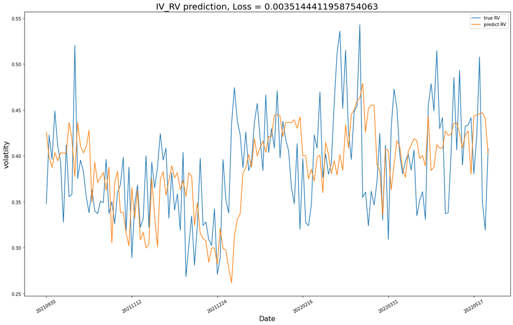

```python
# 準備好Truth data/date
outsample_Y = prep_data.dataset.original_data[len(prep_data.dataset) + window_size::]['daily_RV']
predict_data = prep_data.dataset.original_data[len(prep_data.dataset) + window_size::]['日期'].tolist()
outsample_Y.reset_index(drop = True, inplace = True)

# 計算model out_sample loss
Loss = criterion(torch.FloatTensor(outsample_Y), torch.FloatTensor(outsample_model_prediction).reshape(len(outsample_model_prediction)))
print(f'test_loss = {Loss}')

# 繪圖
plt.figure(figsize = (20,12))
line1 = plt.plot(predict_data,outsample_Y)
line2 = plt.plot(predict_data,outsample_model_prediction)
plt.title(f'IV_RV prediction, Loss = {Loss}', fontsize=20)
plt.xlabel('Date', fontsize=16)
plt.ylabel('volatilty', fontsize=16)
plt.xticks(np.arange(0, len(outsample_Y), step=30),fontsize = 10, rotation = 30) # x刻度 字的大小
plt.legend(['true RV','predict RV'])
#plt.savefig('/Users/robert/Documents/碩士畢業論文/figure_output/IV_RV_train_output.png')
```

## 小結論

很遺憾的我們沒有發現什麼新的方式增進預測能力，但至少我們說明了**IV加權**對於預測沒有什麼太大的幫助。 以下我列了幾點可能的原因：

1. IV加權中，我們使用的IV為**日盤收盤價**所計算而得的IV，但選擇權價格在日內波動是非常劇烈的，也許單一時間點的資料代表性不足
2. 其實在Part 3就可以觀察到，大部分時間，**IV加權**跟**RV**的走勢與變動方向是相同的，且在非常極端的市場衝擊下，選擇權市場也沒有出現提早反應的情況。  
   故這使得I加權並沒辦法提供額外的訊息。

### 我知道這個結果並不讓人振奮，但是我們還沒放棄！

接下來我們將回歸經典，使用傳統計量經濟處理時間序列的模型去做**特徵工程**，並再將結果丟入LSTM中，並看預測的表現有無改善。